# Analisis hogares monoparentales y jefatura femenina en la RM

Manuel Astroza

2025-05-13

# Introducción

El estudio de los hogares monoparentales es fundamental porque permite comprender las dinámicas familiares que afectan tanto el bienestar de los hijos como la situación socioeconómica del hogar. Estos hogares, donde solo uno de los padres está a cargo, enfrentan desafíos particulares, como mayores en la generación de ingresos, pués los hogares biparentales presentan mejores ingresos autónomos: 1,5 veces mayores al de los monoparentales; impactando en la calidad de vida de sus integrantes.

Para los últimos 30 años, se observa que el porcentaje de familias monoparentales aumentó de un 15,6% a un 26,3%, mientras que la proporción de hogares biparentales se redujo de un 71,4% a un 54,1%, alcanzando su mínimo histórico (El Librero, 2024)

La tasa de jefatura femenina en hogares monoparentales es especialmente relevante porque la mayoría de estos hogares están encabezados por mujeres, quienes suelen enfrentar una mayor vulnerabilidad económica.

**Hipótesis**: Los hogares monoparentales con jefas de hogar se presentan en comunas de bajos ingresos.

# Área de estudio

La región metropolitana concentra cerca del 40% de la población nacional y puede ser dividida en zonas norte, centro, sur, oeste y este. Para este estudio se enfocará en entregar una caracterización socioeconómica, que puede ser explicativa para las situaciones de estudio.

- **Zona Norte**: Incluye comunas como Quilicura, Conchalí y Huechuraba. Se caracteriza por un crecimiento urbano acelerado, con una mezcla de sectores industriales y residenciales. Aunque ha habido mejoras en infraestructura, persisten desafíos en acceso a servicios y empleo.
- **Zona Centro**: Comprende Santiago Centro, Providencia y Recoleta. Es el núcleo financiero y comercial de la región, con una alta concentración de empleo y servicios. Sin embargo, enfrenta problemas de congestión, contaminación y desigualdad en el acceso a vivienda.
- **Zona Sur**: Comunas como La Pintana y Puente Alto presentan mayores índices de vulnerabilidad social. La pobreza y el acceso limitado a educación y salud son desafíos clave, aunque también hay iniciativas de desarrollo urbano y comunitario.
- **Zona Oeste**: Incluye Maipú, Pudahuel y Cerro Navia. Es una zona con fuerte crecimiento poblacional y expansión inmobiliaria. A pesar de contar con áreas industriales importantes, la desigualdad en ingresos y acceso a servicios sigue siendo un reto.
- **Zona Este**: Comunas como Las Condes, Vitacura y Lo Barnechea destacan por su alto nivel socioeconómico. Son sectores con mejor infraestructura, acceso a educación y salud de calidad, aunque también enfrentan problemas como el alto costo de vida y la segregación urbana.

# Marco teórico

Familia monoparental: Aquella constituida por un solo progenitor y sus hijos. (BCN, s.f.).

# Metodología

Las librerías a utilizar son:

```r
library(biscale)
library(DBI)
library(RPostgres)
library(sf)
library(ggplot2)
library(cowplot)
```

Posterior se configura la base de datos, coincideiendo con paramatros locales establecidos en pgAdmin

```r
# 1. Definir parámetros de conexión
db_host     = "localhost"       # servidor de BD
db_port     = 5432                # puerto de escucha
db_name     = "censo_rm"   # nombre de la base
db_user     = "postgres"        # usuario de conexión
db_password = "postgres"        # clave de usuario

# Establecer conexión usando RPostgres
con = dbConnect(
  Postgres(),
  dbname   = db_name,
  host     = db_host,
  port     = db_port,
  user     = db_user,
  password = db_password
)
```

Se definen los indicadores y la geometría espacial utilizando códificación de pdAdmin en variables R

```r
# 2. Definir indicadores SQL
sql_indicadores = "
SELECT
  z.geocodigo::double precision AS geocodigo, c.nom_comuna,
  ROUND(  -- porcentaje jefatura femenina
    COUNT(*) FILTER (WHERE p.p08 = 2 AND p.p07 = 1) * 100.0
    / NULLIF(COUNT(*), 0)
  , 2) AS jefatura_f,
  ROUND(  -- porcentaje hogares monoparentales
    COUNT(*) FILTER (WHERE h.tipo_hogar = 2) * 100.0
    / NULLIF(COUNT(*), 0)
  , 2) AS h_monop
FROM public.personas   AS p
JOIN public.hogares    AS h ON p.hogar_ref_id    = h.hogar_ref_id
JOIN public.viviendas  AS v ON h.vivienda_ref_id = v.vivienda_ref_id
JOIN public.zonas      AS z ON v.zonaloc_ref_id   = z.zonaloc_ref_id
JOIN public.comunas    AS c ON z.codigo_comuna    = c.codigo_comuna
GROUP BY z.geocodigo, c.nom_comuna
ORDER BY jefatura_f DESC;
"

# Ejecutar consulta y importar resultados a data.frame en R
df_indicadores = dbGetQuery(con, sql_indicadores)

# 3. Definir geometría espacial de zonas dentro de Santiago urbano en SQL
sql_geometria = "
SELECT
  geocodigo::double precision AS geocodigo,
  geom
FROM dpa.zonas_censales_rm
WHERE nom_provin = 'SANTIAGO'
  AND urbano     = 1;
"
# Leer la capa espacial directamente desde la BD
sf_zonas = st_read(con, query = sql_geometria)
```

Luego se realiza una unión de datos mediante geocodigo

```r
# 4. Merge por geocódigo para obtener un objeto sf con atributos e indicadores
sf_mapa = merge(
  x     = sf_zonas,
  y     = df_indicadores,
  by    = "geocodigo",
  all.x = FALSE  # conservar solo combinaciones existentes
)
```

Con ello es posible generar dos mapas que muestren mediante degradado de un color ambos índices

```r
# 5. Mapa del % de jefatura femenina: relleno por valor de total_profesionales
map_total_jefatura = ggplot(sf_mapa) +
  geom_sf(aes(fill = jefatura_f), color = "#AAAAAA30", size = 0.1) +
  labs(
    title = "Porcentaje de Jefatura femenina",   # título principal
    fill  = "% Jefatura femenina"                # etiqueta de leyenda
  ) +
  theme_minimal()

# Mapa del % de monoparentales: relleno por valor de ptje_mono
map_h_monop = ggplot(sf_mapa) +
  geom_sf(aes(fill = h_monop), color = "#AAAAAA30", size = 0.1) +
  labs(
    title = "Porcentaje de Hogares monoparentales",
    fill  = "% Hogares monoparentales"
  ) +
  theme_minimal()
```

El gráfico de dispersión es creado mediante la definicion de medianas

```r
# 6. Crear gráfico de dispersión
# 6.1 Calcular medianas para dividir cuadrantes
mediana_jefatura = median(sf_mapa$jefatura_f, na.rm = TRUE)
mediana_mono  = median(sf_mapa$h_monop, na.rm = TRUE)

# 6.2 Crear la variable que indica el cuadrante según comparaciones con medianas
sf_mapa$cuadrante = with(
  sf_mapa,
  ifelse(
    jefatura_f >= mediana_jefatura & h_monop >= mediana_mono, 'Q1: Alta/Alta',
    ifelse(
      jefatura_f <  mediana_jefatura & h_monop >= mediana_mono, 'Q2: Baja/Alta',
      ifelse(
        jefatura_f <  mediana_jefatura & h_monop <  mediana_mono, 'Q3: Baja/Baja',
        'Q4: Alta/Baja'
      )
    )
  )
)

# 6.3 Definir paleta de colores manual para cada cuadrante
colores_cuadrantes = c(
  'Q1: Alta/Alta' = '#08519c',  # alto/alto
  'Q2: Baja/Alta' = '#6baed6',  # bajo/alto
  'Q3: Baja/Baja' = '#eff3ff',  # bajo/bajo
  'Q4: Alta/Baja' = '#bdd7e7'   # alto/bajo
)

# 6.4 Construir scatterplot con líneas de mediana
grafico_cuadrantes = ggplot(
  sf_mapa,
  aes(
    x     = jefatura_f,
    y     = h_monop,
    color = cuadrante
  )
) +
  geom_point(size = 2) +  # puntos de cada comuna
  geom_vline(xintercept = mediana_jefatura, linetype = 'dashed', color = 'gray50') +
  geom_hline(yintercept = mediana_mono,  linetype = 'dashed', color = 'gray50') +
  scale_color_manual(name = 'Cuadrante', values = colores_cuadrantes) +
  labs(x = '% Jefatura', y = '% Hogares monoparentales', title = 'Dispersión por Cuadrantes') +
  theme_minimal()
```

```r
# 7 Crear mapa bivariado
# 7.1 Obtener geometría comunal para Santiago
sql_comunas = "
SELECT cut, nom_comuna, geom
FROM dpa.comunas_rm_shp
WHERE nom_provin = 'SANTIAGO';
"
sf_comunas_santiago = st_read(con, query = sql_comunas)

# 7.2 Clasificar datos en 3 x 3 bivariado
sf_mapa_bi = bi_class(sf_mapa, x = jefatura_f, y = h_monop, dim = 3, style = 'jenks')


# 7.3 Calcular bbox y centroides para etiquetas comunales
caja = sf::st_bbox(sf_mapa_bi)
sf_comunas_centroides = st_centroid(sf_comunas_santiago)

# 7.4 Crear mapa bivariado sin bordes internos y con etiquetas
mapa_bivariado_etiquetas = ggplot() +
  geom_sf(data = sf_mapa_bi, aes(fill = bi_class), color = NA, show.legend = FALSE) +
  geom_sf(data = sf_comunas_santiago, fill = NA, color = 'black', size = 0.4) +
  geom_sf_text(data = sf_comunas_centroides, aes(label = nom_comuna), size = 2, fontface = 'bold') +
  bi_scale_fill(pal = 'DkBlue', dim = 3) +
  labs(title = 'Mapa bivariado para Jefatura femenina vs. Hogar monoparental', subtitle = 'Provincia de Santiago, RM') +
  coord_sf(xlim = c(caja['xmin'], caja['xmax']), ylim = c(caja['ymin'], caja['ymax']), expand = FALSE) +
  theme_void() +
  theme(plot.title = element_text(hjust = 0.5, face = 'bold'), plot.subtitle = element_text(hjust = 0.5))

# 7.5 Generar y posicionar leyenda bivariada
leyenda_bivariada = bi_legend(pal = 'DkBlue', dim = 3, xlab = '% Jefatura femina', ylab = '% Hogar monoparental', size = 8)
mapa_final = ggdraw() +
  draw_plot(mapa_bivariado_etiquetas, x = 0,    y = 0,    width = 1,    height = 1) +
  draw_plot(leyenda_bivariada,          x = 0.75, y = 0.05, width = 0.25, height = 0.25)
```

Finalmente se contruye un mapa bivariado

# Resultados

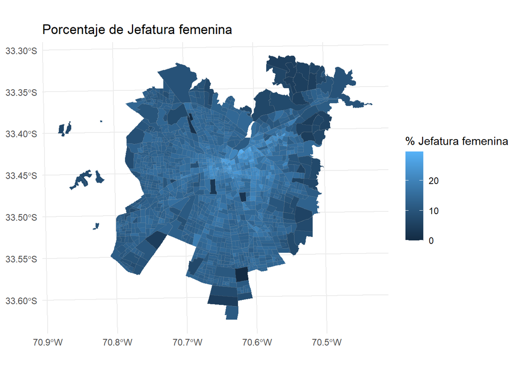

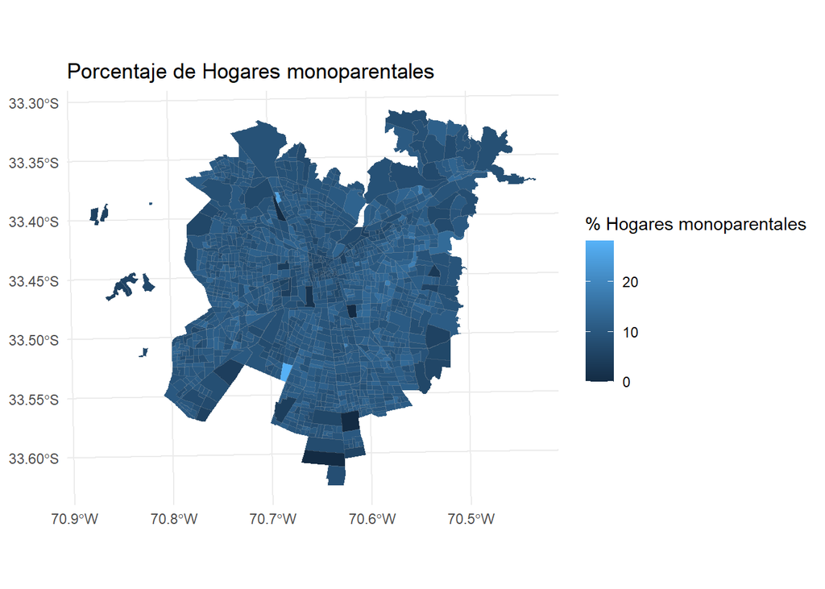

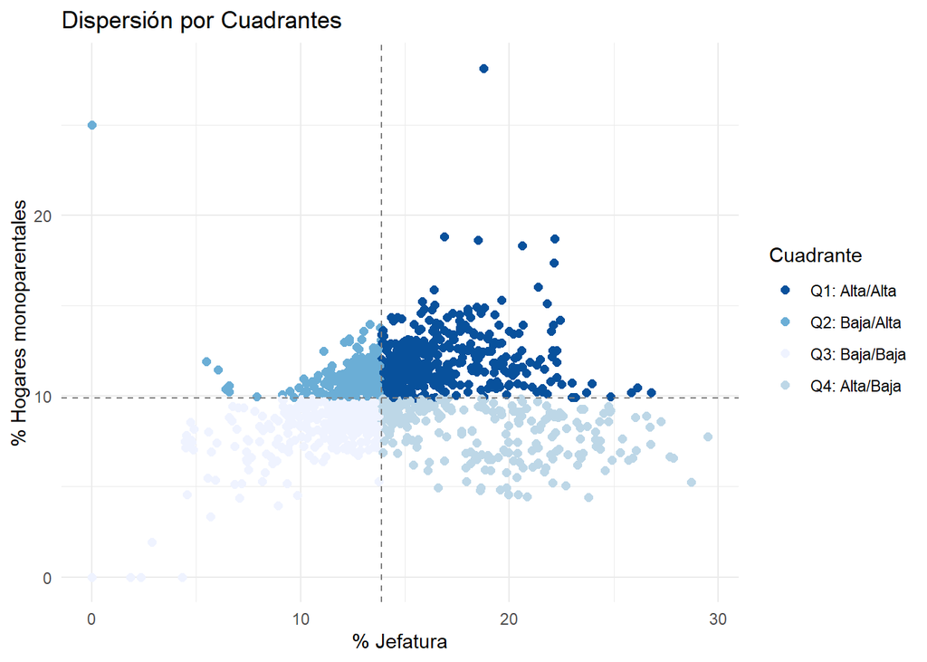

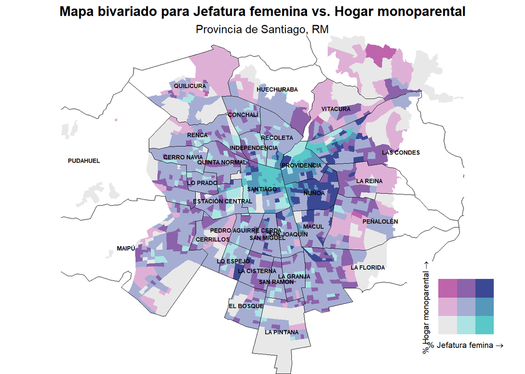

# Análisis

Respecto a las tasas de jefatura femenina se observa mayor concentración de la misma en el centro de Santiago (colores claros) y menores índices en los extremos de la Región, destacando La Pintana y Vitacura, dónde el índice es bajo en toda la comuna y no solo los exteriores.

El índice de hogares monoparentales es más uniforme, más sigue la misma tendencia de disminuir hacia los exteriores. El menor índice con diferencia se registra en La Pintana.

El gráfico de dispersión por cuadrantes confirma la correlación, evidenciando mayores relaciones bajo-bajo y alto-alto entre jefatura femenina y hogares monoparentales. Sin embargo, también es notable la relación alta-baja, indicando que también se presentan casos de jefatura femenina sin ser un hogar monoparental. Estos casos podrían referir a mujeres solteras u hogares sin hijos, lo cuál ha sido tendencia los últimos años.

En el mapa bivariado se observan cuatro grandes tendencias. En el centro (Santiago) los mayores porcentajes de jefatura femenina sin que el hogar sea monoparental. Es posible que muchas mujeres independientes u hogares sin hijos vivan en departamentos, que son comunes en esta zona.

En las zonas Oeste y Norte predomina una correlación entre ambas variables, más ambas presentando porcentajes medios. Estas comunas presentan heterogeneidad económica, con variaciones de ingresos. Es importante destacar que presentan mala conectividad, por lo que deberían ser evaluadas para la implementación de políticas.

Finalmente en los extremos de las comunas más alejadas del centro se presentan los menores índices de ambas variables correlacionadas, indicando mayor presencia de familias “más tradicionales”.

# Conclusión

También se presentan casos excepcionales como Santiago centro con alto índice de jefatura femenina sin pertenecer a hogares monoparentales, que bien puede referir a mujeres independientes o sin hijos que habiten departamentos o la zona sur-oeste con gran variación.

Para futuros análisis se podría considerar más índices que expliquen estas situaciones.

# Bibliografía

Biblioteca del Congreso Nacional de Chile. (s. f.). La familia. BCN. https://www.bcn.cl/formacioncivica/detalle_guia?h=10221.3/45665 Lira, J. P. (2024, 10 julio). La estrecha relación entre composición familiar y vulnerabilidad social. El Líbero. https://ellibero.cl/ensayos-asuntos-publicos/la-estrecha-relacion-entre-composicion-familiar-y-vulnerabilidad-social/